# Transaction Data - Part I: Cleaning and EDA

Transaction level data is invaluable to businesses looking to understand their customers. This series will take a take a close look at the Online Retail dataset available on the UCI Machine Learning Repository.

The dataset contains all transactions between 01/12/2009 and 09/12/2011 occurring for a UK-based non-store online retail company. The company mainly sells unique all-occasion gift-ware and many of its' customers are wholesalers.

## Mount drive and import libraries and data

```python
# mount drive
from google.colab import drive
drive.mount('/content/drive')
```

```python
# import libraries
import pandas as pd
import matplotlib.pyplot as plt
plt.style.use('fivethirtyeight')
import seaborn as sns
import numpy as np
import datetime as dt
```

```python
# import data
df1 = pd.read_csv("./drive/My Drive/Data/EDA/online_retail_2.csv")
df2 = pd.read_csv("./drive/My Drive/Data/EDA/online_retail_1.csv")
```

## Merge dataframes

```python
# inspect the two dataframes
df1.head(2)
```

|  | Unnamed: 0 | Invoice | StockCode | Description | Quantity | InvoiceDate | Price | Customer ID | Country |
| --- | --- | --- | --- | --- | --- | --- | --- | --- | --- |
| 0 | 0 | 489434 | 85048 | 15CM CHRISTMAS GLASS BALL 20 LIGHTS | 12 | 2009-12-01 07:45:00 | 6.95 | 13085.0 | United Kingdom |
| 1 | 1 | 489434 | 79323P | PINK CHERRY LIGHTS | 12 | 2009-12-01 07:45:00 | 6.75 | 13085.0 | United Kingdom |

```python
df2.head(2)
```

|  | Unnamed: 0 | InvoiceNo | StockCode | Description | Quantity | InvoiceDate | UnitPrice | CustomerID | Country |
| --- | --- | --- | --- | --- | --- | --- | --- | --- | --- |
| 0 | 0 | 536365 | 85123A | WHITE HANGING HEART T-LIGHT HOLDER | 6 | 2010-12-01 08:26:00 | 2.55 | 17850.0 | United Kingdom |
| 1 | 1 | 536365 | 71053 | WHITE METAL LANTERN | 6 | 2010-12-01 08:26:00 | 3.39 | 17850.0 | United Kingdom |

Upon inspection, it appears as though the two dataframes have slightly different column names. We will need to resolve this before merging the two dataframes.

```python
# change df2 column names to df1
df1.columns = df2.columns

# lets merge the two dataframes using the pandas concat function
df = pd.concat([df1, df2])

# inspect
df.head()
```

|  | Unnamed: 0 | InvoiceNo | StockCode | Description | Quantity | InvoiceDate | UnitPrice | CustomerID | Country |
| --- | --- | --- | --- | --- | --- | --- | --- | --- | --- |
| 0 | 0 | 489434 | 85048 | 15CM CHRISTMAS GLASS BALL 20 LIGHTS | 12 | 2009-12-01 07:45:00 | 6.95 | 13085.0 | United Kingdom |
| 1 | 1 | 489434 | 79323P | PINK CHERRY LIGHTS | 12 | 2009-12-01 07:45:00 | 6.75 | 13085.0 | United Kingdom |
| 2 | 2 | 489434 | 79323W | WHITE CHERRY LIGHTS | 12 | 2009-12-01 07:45:00 | 6.75 | 13085.0 | United Kingdom |
| 3 | 3 | 489434 | 22041 | RECORD FRAME 7" SINGLE SIZE | 48 | 2009-12-01 07:45:00 | 2.10 | 13085.0 | United Kingdom |
| 4 | 4 | 489434 | 21232 | STRAWBERRY CERAMIC TRINKET BOX | 24 | 2009-12-01 07:45:00 | 1.25 | 13085.0 | United Kingdom |

```python
# drop the 'Unnamed: 0' column
df = df.drop(['Unnamed: 0'], axis=1)

# drop duplicates
df.drop_duplicates(inplace=True)
```

## Inspect

Now that we've got our combined dataset, let's take a look at its contents.

```python
# how many entries are there? what data types are in each column? any missing values?
df.info()
```

```
<class 'pandas.core.frame.DataFrame'>
Int64Index: 1033035 entries, 0 to 541908
Data columns (total 8 columns):
 #   Column       Non-Null Count    Dtype
---  ------       --------------    -----
 0   InvoiceNo    1033035 non-null  object
 1   StockCode    1033035 non-null  object
 2   Description  1028760 non-null  object
 3   Quantity     1033035 non-null  int64
 4   InvoiceDate  1033035 non-null  object
 5   UnitPrice    1033035 non-null  float64
 6   CustomerID   797884 non-null   float64
 7   Country      1033035 non-null  object
dtypes: float64(2), int64(1), object(5)
memory usage: 70.9+ MB
```

```python
# check proportion of NA's
df.isna().mean()
```

```
InvoiceNo      0.000000
StockCode      0.000000
Description    0.004138
Quantity       0.000000
InvoiceDate    0.000000
UnitPrice      0.000000
CustomerID     0.227631
Country        0.000000
dtype: float64
```

```python
# convert InvoiceDate to DateTime object
df.InvoiceDate = pd.to_datetime(df.InvoiceDate)

# create a value column, the product of unit and price
df['Revenue'] = df.Quantity * df.UnitPrice
```

The main focus of this notebook is to look at customer spending so lets take a quick look at some summary statistics of Quantity, Unit Price and Value

```python
df[['Quantity', 'UnitPrice', 'Revenue']].agg(['min', 'max', 'mean', 'median'])
```

|  | Quantity | UnitPrice | Revenue |
| --- | --- | --- | --- |
| min | -80995.000000 | -53594.360000 | -168469.600000 |
| max | 80995.000000 | 38970.000000 | 168469.600000 |
| mean | 10.076888 | 4.613967 | 18.252543 |
| median | 3.000000 | 2.100000 | 9.920000 |

The presence of negative values suggests that there's more than just outgoing sales transactions included in this dataset.

## Transaction types

```python
print('Entries w/ Quantity or UnitPrice <= 0 : ', ((df.Quantity <= 0) | (df.UnitPrice <= 0)).sum())
print('Entries w/ Quantity and UnitPrice <= 0 : ', ((df.Quantity <= 0) & (df.UnitPrice <= 0)).sum())
```

```
Entries w/ Quantity or UnitPrice <= 0 :  25122
Entries w/ Quantity and UnitPrice <= 0 :  3393
```

### Stock Codes

Stock codes codes appear to have a standardised format that includes numbers and letters. Filtering on stockcodes without numbers reveals the several codes not pertaining to particular products.

```python
df[~df.StockCode.str.contains('[0-9]')].groupby(['StockCode', 'Description'])['InvoiceNo'].size()
```

```
StockCode     Description
ADJUST        Adjustment by Peter on 24/05/2010 1       3
              Adjustment by john on 26/01/2010 16      38
              Adjustment by john on 26/01/2010 17      26
AMAZONFEE     AMAZON FEE                               36
B             Adjust bad debt                           6
BANK CHARGES   Bank Charges                             6
              Bank Charges                             94
CRUK          CRUK Commission                          16
D             Discount                                173
DCGSSBOY      BOYS PARTY BAG                           21
              update                                    1
DCGSSGIRL     GIRLS PARTY BAG                          23
              update                                    1
DOT           DOTCOM POSTAGE                         1423
M             Manual                                 1387
PADS          PADS TO MATCH ALL CUSHIONS               19
POST          POSTAGE                                2078
S             SAMPLES                                 101
m             Manual                                    5
Name: InvoiceNo, dtype: int64
```

### Sales

Sales will be defined as those entries with:

1. A quantity and unit price greater than 0
2. Invoice not beginning with 'C' (see 'cancellation and returns')
3. A valid stock code

```python
sales = df[(df.Quantity > 0) & (df.UnitPrice > 0)]
sales = sales[~sales.InvoiceNo.str.startswith('C')]
sales = sales[sales.StockCode.str.contains('[0-9]')]
```

```python
sales.shape
```

```
(1003653, 9)
```

```python
# save to sales to csv for future use
#sales.to_csv("./drive/My Drive/Data/EDA/sales.csv")
#sales = pd.read_csv("./drive/My Drive/Data/EDA/sales.csv")
#sales['InvoiceDate'] = pd.to_datetime(sales['InvoiceDate'])
```

### Cancellations & Returns

Invoices starting with 'C' are understood to represent returns or cancellations. With the exception of C496350, all invoices starting with 'C' have negative quantities and positive unit prices. This is assumed to be an adjustment (and therefore removed from sales).

```python
# create return dataframe
returns = df[df.InvoiceNo.str.startswith('C')]
```

```python
# logical check of 'C'
returns_check = df[(df.Quantity < 0) & (df.UnitPrice > 0)]
print('Count of invoices starting with "C" : ' , len(returns))
print('Count of invoices w/ quantity < 0 & price > 0: ' , len(returns_check))
print('Count of difference : ', len(returns) - len(returns_check))
print('the culprit:')
returns[returns.Quantity >= 0]
```

```
Count of invoices starting with "C" :  19104
Count of invoices w/ quantity < 0 & price > 0:  19103
Count of difference :  1
the culprit:
```

|  | InvoiceNo | StockCode | Description | Quantity | InvoiceDate | UnitPrice | CustomerID | Country | Revenue |
| --- | --- | --- | --- | --- | --- | --- | --- | --- | --- |
| 76799 | C496350 | M | Manual | 1 | 2010-02-01 08:24:00 | 373.57 | NaN | United Kingdom | 373.57 |

```python
# filter on stock codes containing numbers
returns = returns[returns.StockCode.str.contains('[0-9]')]
```

```python
print('value of returns : £' , round(-returns.Revenue.sum()))
print('% of sales revenue : ' , round(-returns.Revenue.sum() / sales.Revenue.sum() * 100, 2) , '%')
print('count of returns : ', round(-returns.Quantity.sum()))
print('% of sales volume : ' , round(-returns.Quantity.sum() / sales.Quantity.sum() * 100, 2) , '%')
```

```
value of returns : £ 716808
% of sales revenue :  3.65 %
count of returns :  467752
% of sales volume :  4.18 %
```

# Sales analysis

## Trend and Seasonality

```python
monthly_sales = sales.resample('M', on='InvoiceDate', convention='end')[['Revenue', 'Quantity']].sum()
monthly_sales.columns = ['Revenue', 'Volume']
monthly_sales['Rev_RollingAvg_12m'] = monthly_sales.Revenue.rolling(12).mean()
monthly_sales['Vol_RollingAvg_12m'] = monthly_sales.Volume.rolling(12).mean()
```

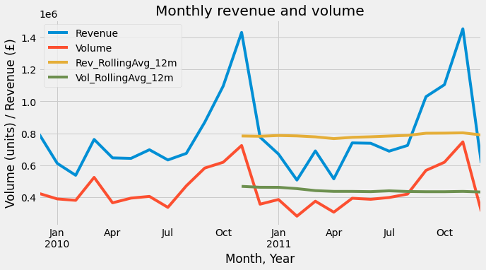

```python
monthly_sales.plot(figsize=(10,5))
plt.title('Monthly revenue and volume')
plt.ylabel('Volume (units) / Revenue (£)')
plt.xlabel('Month, Year')
plt.legend()
plt.show()
```

Commentary:

- Monthly revenue and volume highly seasonal reaching c. £1.4m in the lead up to Christmas and less c. £0.5m off peak.
- 12 month rolling average doesnt indicate any significant trend in revenue or volume.

## Country Analysis

Analysing sales at the country and regional level might help us to identify any growth markets and/or declining markets and inform business development strategy.

```python
print(sales.Country.nunique(),' countries')
print(sales.Country.unique())
```

```
43  countries
['United Kingdom' 'France' 'Australia' 'EIRE' 'Germany' 'Portugal'
 'Denmark' 'Netherlands' 'Poland' 'Channel Islands' 'Spain' 'Cyprus'
 'Belgium' 'Greece' 'Norway' 'Austria' 'Sweden' 'United Arab Emirates'
 'Finland' 'Italy' 'Switzerland' 'USA' 'Japan' 'Unspecified' 'Malta'
 'Bahrain' 'RSA' 'Bermuda' 'Hong Kong' 'Singapore' 'Thailand' 'Israel'
 'Lithuania' 'Nigeria' 'West Indies' 'Lebanon' 'Korea' 'Brazil' 'Canada'
 'Iceland' 'Saudi Arabia' 'Czech Republic' 'European Community']
```

With 42 named countries and 1 unspecified country, it would help to put these markets into perspective. Let's look at what proportion each of the top 5 countries represent of the total revenue for 2011.

```python
sales11 = sales[sales.InvoiceDate.dt.year == 2011]
sales11.groupby('Country').Revenue.sum().div(sales11.Revenue.sum()).sort_values(ascending=False).round(2).head(5)
```

```
Country
United Kingdom    0.85
Netherlands       0.03
EIRE              0.03
Germany           0.02
France            0.02
Name: Revenue, dtype: float64
```

As a UK based company it is perhaps not entirely surprising that the UK market makes up a large portion of total sales.

Let's split create a new category 'region' to distinguish between UK and international (i.e. non-UK) sales.

```python
sales.loc[sales['Country'] != 'United Kingdom', 'Region'] = 'International'
sales.loc[sales['Country'] == 'United Kingdom', 'Region'] = 'UK'
```

We know that the UK market generates 85% of revenue but how do the two 'regions' compare in terms of growth.

Lets define a function to compare rolling 12 month growth trends any given categorical variable (i.e. 'region', 'country', 'customer').

```python
def growth_plot(df, group, date, start, measure, topx):
  monthly = df[df[date].dt.year >= start].groupby([group, pd.Grouper(key=date, freq="M")])[measure].sum()\
            .unstack(1).fillna(0).transpose()
  r12_sum = monthly.rolling(12).sum().dropna(axis=0)
  r12_growth = r12_sum.div(r12_sum.iloc[0]) *100
  top5 = r12_sum.iloc[-1].sort_values(ascending=False).head(topx)
  top5_list = top5.keys().to_list()
  r12_growth[top5_list].plot(figsize=(10,5))
  plt.title('Rolling 12m Growth for Top ' + str(topx) + ' ' + group + "'s")
  plt.xlabel('Date')
  plt.ylabel('Percentage')
```

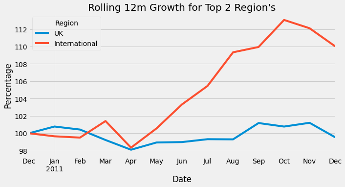

```python
growth_plot(sales, 'Region', 'InvoiceDate', 2010, 'Revenue', 2)
```

Commentary:

With 15% of revenue split across 40 countries, it is perhaps most valuable to focus on the countries generating the significant amounts of revenue. Lets look at the Top 6 countries (inc. UK) as they all generate an excess of £100,000.

```python
sales11.groupby('Country').Revenue.sum().sort_values(ascending=False).head(10).round()
```

```
Country
United Kingdom    8020950.0
Netherlands        275135.0
EIRE               266058.0
Germany            192137.0
France             175999.0
Australia          137138.0
Spain               54003.0
Switzerland         51841.0
Belgium             35327.0
Sweden              32995.0
Name: Revenue, dtype: float64
```

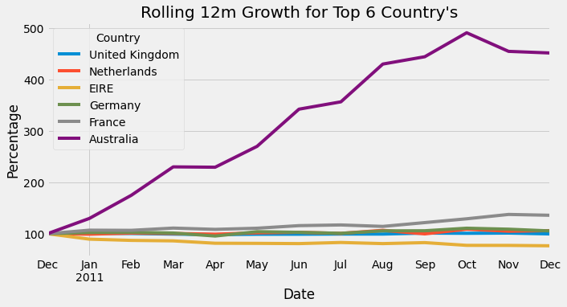

```python
growth_plot(sales, 'Country', 'InvoiceDate', 2010, 'Revenue', 6)
```

Evidently, Australia is a major growth market for this business whilst EIRE has declined over the period.

## Product Analysis

This section aims to provide a high level view of the number of unique products sold and the proportion of revenue these products represent.

```python
print(sales.StockCode.nunique(), 'unique products sold over the two year period (2010-2011)')
```

```
4904 unique products sold over the two year period (2010-2011)
```

```python
def new_unique(df, group, date, period):
  unique = sales.resample(period, on=date, convention='end')[group].nunique()\
          .reset_index().set_index(date)
  min = sales.groupby(group)[date].min().reset_index()\
        .resample(period, on=date)[group].count().cumsum()
  nu = pd.merge(unique, min, on=date)
  nu.columns = ['Unique_in_Month', 'Unique_Cumulative']
  nu.plot(figsize=(10,5))
  plt.fill_between(nu.index, 0, nu.Unique_in_Month, alpha= 0.3)
  plt.fill_between(nu.index, nu.Unique_in_Month, nu.Unique_Cumulative, alpha= 0.3)
  plt.title('Unique monthly and cumulative ' + group + "'s")
  plt.ylabel('Unique ' + group + "'s")
  plt.xlabel('Month, Year')
  plt.show()
```

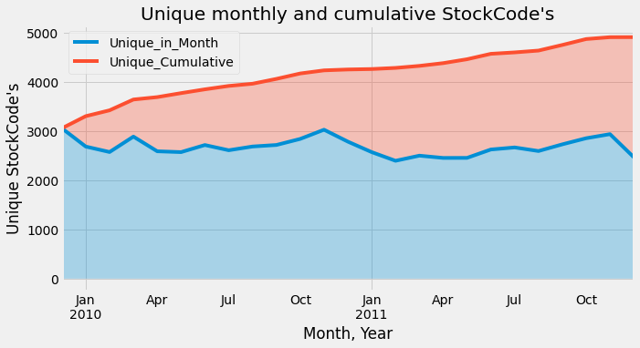

```python
new_unique(sales, 'StockCode', 'InvoiceDate', 'M')
```

Commentary:

- Between 2500 and 3000 unique products sold monthly.
- Peak unique products sold reached in lead up to Christmas
- Reduction in unique products sold during off-peak season in 2011 vs 2010.
- Steady growth in cumulative unique products sold over period suggesting regular new product launches.

### Proportion

```python
def prop_plot(df, yr, date, group, value):
  df2 = df[df[date].dt.year == yr].groupby(group)[value].sum()\
      .sort_values(ascending=False).reset_index()
  df2['cvalue'] = df2[value].cumsum()
  # note groupby has filtered out any NA's, thus divide by sum of main df
  tot_val = df[df[date].dt.year == yr][value].sum()
  df2['cvalue_prop'] = df2['cvalue'] / tot_val
  df2['count'] = np.arange(1,(len(df2)+1))
  df2['count_prop'] = df2['count'] / (len(df2)+1)
  df_prop = df2[['count_prop', 'cvalue_prop']].set_index('count_prop')
  df_prop.plot(figsize=(5,5), label = 'proportion')
  plt.fill_between(df_prop.index, 0, df_prop.cvalue_prop, alpha= 0.3)
  plt.title(group + ' vs. ' + value + ' for ' + str(yr))
  plt.ylabel('Proportion of ' + value)
  plt.xlabel('Proportion of ' + group + "'s")
  plt.ylim(0,1.01)
  plt.xlim(0,1.01)
  plt.legend().remove()
  plt.show()
```

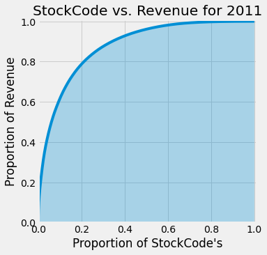

```python
prop_plot(sales, 2011, 'InvoiceDate', 'StockCode', 'Revenue')
```

Commentary:

- 20% of products account for 80% of revenue in 2011
- 40% of products account for less than 5% of revenue in 2011

## Customer Analysis

This section aims to provide a high level view of the number of unique customers purchasing from the business and the proportion of revenue these customers represent.

```python
print(sales.CustomerID.nunique(), 'unique named customers over period 2010 and 2011')
```

```
5853 unique named customers over period 2010 and 2011
```

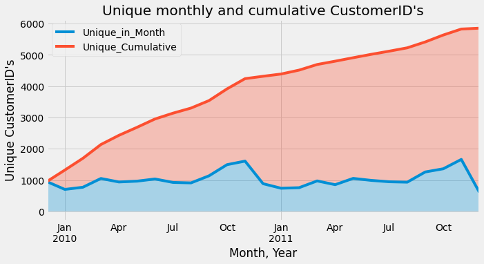

```python
new_unique(sales, 'CustomerID', 'InvoiceDate', 'M')
```

Commentary:

- Between 800 and 1600 monthly unique customers over 2 year period with seasonal peaks around Christmas
- Steady increase in new customers over 2 year period.
- 6000 unique customers made purchases over period, suggesting a low retention rate.

### Proportion

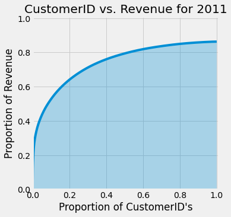

```python
prop_plot(sales, 2011, 'InvoiceDate', 'CustomerID', 'Revenue')
```

Commentary:

- Top 20% of customers account for 65% of revenue
- 15% of revenue is derived from unnamed customers

```python
!jupyter nbconvert --to html Transaction_Data_Part_1.ipynb
```